# Credit_Card_Fraud_Detection

Sayari

Develop a model to identify fraudulent transactions.

This dataset presents transactions that occurred in two days, where we have 492 frauds out of 284,807 transactions. The dataset is highly unbalanced, the positive class (frauds) account for 0.172% of all transactions. Except Time, Amount and Class columns the other columns from V1 to V28 are unexplainable and confidential numbers.

Data Wrangling

```
## character(0)
```

```
##   Time        V1          V2        V3        V4          V5          V6
## 1    0 -1.359807 -0.07278117 2.5363467 1.3781552 -0.33832077  0.46238778
## 2    0  1.191857  0.26615071 0.1664801 0.4481541  0.06001765 -0.08236081
##            V7         V8         V9         V10        V11        V12
## 1  0.23959855 0.09869790  0.3637870  0.09079417 -0.5515995 -0.6178009
## 2 -0.07880298 0.08510165 -0.2554251 -0.16697441  1.6127267  1.0652353
##          V13        V14       V15        V16        V17         V18
## 1 -0.9913898 -0.3111694 1.4681770 -0.4704005  0.2079712  0.02579058
## 2  0.4890950 -0.1437723 0.6355581  0.4639170 -0.1148047 -0.18336127
##         V19         V20         V21        V22        V23         V24
## 1  0.403993  0.25141210 -0.01830678  0.2778376 -0.1104739  0.06692807
## 2 -0.145783 -0.06908314 -0.22577525 -0.6386720  0.1012880 -0.33984648
##         V25        V26          V27         V28 Amount Class
## 1 0.1285394 -0.1891148  0.133558377 -0.02105305 149.62     0
## 2 0.1671704  0.1258945 -0.008983099  0.01472417   2.69     0
```

```
## [1] " no of frauds" "492"
```

```
##          V1          V2        V3        V4          V5          V6
## 1 -1.359807 -0.07278117 2.5363467 1.3781552 -0.33832077  0.46238778
## 2  1.191857  0.26615071 0.1664801 0.4481541  0.06001765 -0.08236081
##            V7         V8         V9         V10        V11        V12
## 1  0.23959855 0.09869790  0.3637870  0.09079417 -0.5515995 -0.6178009
## 2 -0.07880298 0.08510165 -0.2554251 -0.16697441  1.6127267  1.0652353
##          V13        V14       V15        V16        V17         V18
## 1 -0.9913898 -0.3111694 1.4681770 -0.4704005  0.2079712  0.02579058
## 2  0.4890950 -0.1437723 0.6355581  0.4639170 -0.1148047 -0.18336127
##         V19         V20         V21        V22        V23         V24
## 1  0.403993  0.25141210 -0.01830678  0.2778376 -0.1104739  0.06692807
## 2 -0.145783 -0.06908314 -0.22577525 -0.6386720  0.1012880 -0.33984648
##         V25        V26          V27         V28 Amount Class
## 1 0.1285394 -0.1891148  0.133558377 -0.02105305 149.62     0
## 2 0.1671704  0.1258945 -0.008983099  0.01472417   2.69     0
```

```
## [1] 200000     30
```

# Classification Algorithms - Naive Bayes

Before PCA

```
##
## Naive Bayes Classifier for Discrete Predictors
##
## Call:
## naiveBayes.default(x = as.matrix(x_train), y = factor(y_train))
##
## A-priori probabilities:
## factor(y_train)
##       0       1
## 0.99833 0.00167
##
## Conditional probabilities:
##                V1
## factor(y_train)         [,1]     [,2]
##               0  0.007903952 1.935625
##               1 -4.831154239 6.811838
##
##                V2
## factor(y_train)         [,1]     [,2]
##               0 -0.005161317 1.646375
##               1  3.591932979 4.350533
##
##                V3
## factor(y_train)        [,1]     [,2]
##               0  0.01323081 1.457627
##               1 -6.96000597 7.118649
##
##                V4
## factor(y_train)         [,1]     [,2]
##               0 -0.005223221 1.399436
##               1  4.488476409 2.812871
##
##                V5
## factor(y_train)         [,1]     [,2]
##               0  0.006609917 1.343361
##               1 -3.201350058 5.398700
##
##                V6
## factor(y_train)          [,1]     [,2]
##               0  0.0009866149 1.323551
```

[output cut: 101 more lines]

```
##
##                V27
## factor(y_train)         [,1]      [,2]
##               0 0.0001870468 0.3925276
##               1 0.1902265256 1.3665720
##
##                V28
## factor(y_train)          [,1]      [,2]
##               0 -0.0003682787 0.3312778
##               1  0.0809286825 0.5288363
##
##                Amount
## factor(y_train)      [,1]     [,2]
##               0  87.91934 248.8561
##               1 121.75006 240.8422
```

```
##
## pred_Bayes1     0     1
##           0 82827    26
##           1  1822   132
```

# Chisq test

```
##
##  Pearson's Chi-squared test with Yates' continuity correction
##
## data:  bayesConfusionMatrix1
## X-squared = 4605.2, df = 1, p-value < 2.2e-16
```

# Metrics

```
## [1] "BayesAccuracy1"    "0.978209345926633"
```

```
## [1] "Bayes_precision1"  "0.999686191206112"
```

```
## [1] "Bayes_recall1"     "0.978475823695495"
```

```
## [1] "Bayes_Spec1"       "0.835443037974684"
```

```
## [1] "Bayes_F1_1"        "0.988967295912885"
```

checking bayes for cut off =1

```
##
## predict     0     1
##       0 83759    42
##       1   890   116
```

# Linear discriminant analysis

```
## Call:
## lda((y_train) ~ as.matrix(x_train1))
##
## Prior probabilities of groups:
##       0       1
## 0.99833 0.00167
##
## Group means:
##   as.matrix(x_train1)V1 as.matrix(x_train1)V2 as.matrix(x_train1)V3
## 0           0.007903952          -0.005161317            0.01323081
## 1          -4.831154239           3.591932979           -6.96000597
##   as.matrix(x_train1)V4 as.matrix(x_train1)V5 as.matrix(x_train1)V6
## 0          -0.005223221           0.006609917          0.0009866149
## 1           4.488476409          -3.201350058         -1.3403022480
##   as.matrix(x_train1)V7 as.matrix(x_train1)V8 as.matrix(x_train1)V9
## 0            0.00792044          0.0004624303           0.005878499
## 1           -5.56180870          0.4884512517          -2.605807271
##   as.matrix(x_train1)V10 as.matrix(x_train1)V11 as.matrix(x_train1)V12
## 0             0.01068207           -0.007612328               0.010889
## 1            -5.58379456            3.740707287              -6.127324
##   as.matrix(x_train1)V13 as.matrix(x_train1)V14 as.matrix(x_train1)V15
## 0           -0.000956564             0.01286634            0.001244678
## 1           -0.132991509            -6.87287856           -0.134132158
##   as.matrix(x_train1)V16 as.matrix(x_train1)V17 as.matrix(x_train1)V18
## 0            0.007232588              0.0116446            0.003625185
## 1           -4.071889868             -6.7870695           -2.258650455
##   as.matrix(x_train1)V19 as.matrix(x_train1)V20 as.matrix(x_train1)V21
## 0           -0.002733696           0.0002339332          -0.0001041223
## 1            0.662032063           0.3266317901           0.7976749715
##   as.matrix(x_train1)V22 as.matrix(x_train1)V23 as.matrix(x_train1)V24
## 0           -0.001208996          -0.0001853151           -0.000283132
## 1           -0.018767658           0.0285442808           -0.093959517
##   as.matrix(x_train1)V25 as.matrix(x_train1)V26 as.matrix(x_train1)V27
## 0           0.0005922872           0.0003984991           0.0001870468
## 1           0.0682087436           0.0612372266           0.1902265256
##   as.matrix(x_train1)V28 as.matrix(x_train1)Amount
## 0          -0.0003682787                  87.91934
## 1           0.0809286825                 121.75006
##
## Coefficients of linear discriminants:
```

[output cut: 15 more lines]

```
## as.matrix(x_train1)V15    -0.0096960559
## as.matrix(x_train1)V16    -0.4576938379
## as.matrix(x_train1)V17    -0.8022642755
## as.matrix(x_train1)V18    -0.2802021605
## as.matrix(x_train1)V19     0.0936315690
## as.matrix(x_train1)V20     0.0052569121
## as.matrix(x_train1)V21     0.0991228779
## as.matrix(x_train1)V22     0.0102121998
## as.matrix(x_train1)V23     0.0132787168
## as.matrix(x_train1)V24    -0.0239137795
## as.matrix(x_train1)V25     0.0229649775
## as.matrix(x_train1)V26     0.0239875659
## as.matrix(x_train1)V27     0.0943645687
## as.matrix(x_train1)V28     0.0514289659
## as.matrix(x_train1)Amount  0.0003767887
```

# Confusion Matrix

```
##          y_test
## pred_Lda1     0     1
##         0 84628    35
##         1    21   123
```

# Metrics

```
## [1] "Lda_Accuracy1"     "0.999339677149292"
```

```
## [1] "Lda_precision1"    "0.999586596269917"
```

```
## [1] "Lda_recall1"       "0.999751916738532"
```

```
## [1] "Lda_Spec1"         "0.778481012658228"
```

```
## [1] "Lda_F1_1"         "0.99966924966925"
```

# Classification

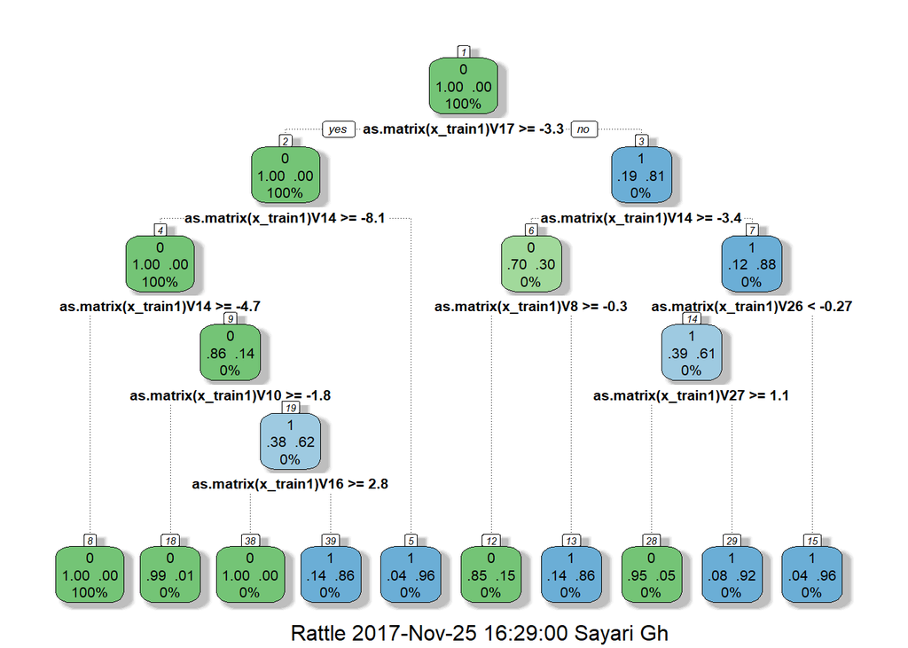

# Confusion Matrix

```
##            y_test
## pred_CTree1     0     1
##           0 84632    33
##           1    17   125
```

# Chisq Test

```
##
##  Pearson's Chi-squared test with Yates' continuity correction
##
## data:  cTreeConfusionMatrix1
## X-squared = 58548, df = 1, p-value < 2.2e-16
```

# Metrics

```
## [1] "cTree_accuracy1"   "0.999410426026153"
```

```
## [1] "cTree_precision1"  "0.999610228547806"
```

```
## [1] "cTree_recall1"     "0.999799170693097"
```

```
## [1] "cTree_Spec1"       "0.791139240506329"
```

```
## [1] "cTree_F1_1"        "0.999704690693032"
```

# C4.5

```
##
## === Summary ===
##
## Correctly Classified Instances      199934               99.967  %
## Incorrectly Classified Instances        66                0.033  %
## Kappa statistic                          0.8916
## Mean absolute error                      0.0006
## Root mean squared error                  0.018
## Relative absolute error                 19.4317 %
## Root relative squared error             44.1142 %
## Total Number of Instances           200000
##
## === Confusion Matrix ===
##
##       a      b   <-- classified as
##  199662      4 |      a = 0
##      62    272 |      b = 1
```

# Confusion Matrix

```
##            y_test
## pred_C4.5_1     0     1
##           0 84638    43
##           1    11   115
```

# Chisq Test

```
##
##  Pearson's Chi-squared test with Yates' continuity correction
##
## data:  C4.5ConfusionMatrix1
## X-squared = 55807, df = 1, p-value < 2.2e-16
```

# Metrics

```
## [1] "C4.5_accuracy1"    "0.999363260108246"
```

```
## [1] "C4.5_precision1"   "0.999492211948371"
```

```
## [1] "C4.5_recall1"      "0.999870051624945"
```

```
## [1] "C4.5_Spec1"        "0.727848101265823"
```

```
## [1] "C4.5_F1_1"         "0.999681096084569"
```

# C5.0

```
##
## Call:
## C5.0.default(x = x_train, y = factor(y_train), trials = 20, rules = FALSE)
##
## Classification Tree
## Number of samples: 200000
## Number of predictors: 29
##
## Number of boosting iterations: 20 requested;  13 used due to early stopping
## Average tree size: 9.5
##
## Non-standard options: attempt to group attributes
```

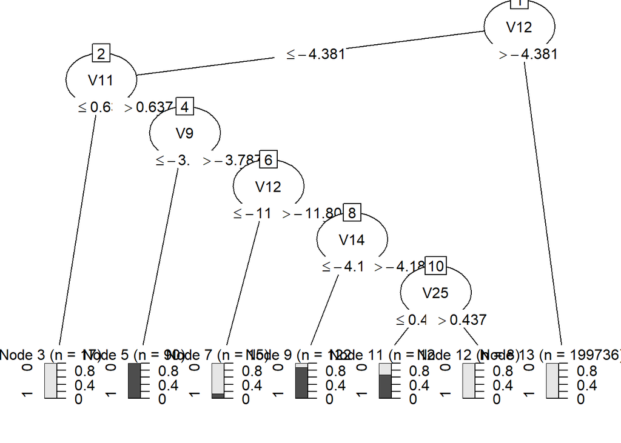

# Confusion Matrix

```
##            y_test
## pred_C5.0_1     0     1
##           0 84625    29
##           1    24   129
```

# Chisq Test

```
##
##  Pearson's Chi-squared test with Yates' continuity correction
##
## data:  C5.0ConfusionMatrix1
## X-squared = 57883, df = 1, p-value < 2.2e-16
```

# Metrics

```
## [1] "C5.0_Accuracy1"    "0.999375051587723"
```

```
## [1] "C5.0_precision1"   "0.999657429064191"
```

```
## [1] "C5.0_recall1"      "0.999716476272608"
```

```
## [1] "C5.0_Spec1"        "0.816455696202532"
```

```
## [1] "C5.0_F1_1"         "0.999686951796483"
```

# Logit

```
##
## Call:  glm(formula = y_train ~ as.matrix(x_train1), family = binomial(link = "logit"))
##
## Coefficients:
##               (Intercept)      as.matrix(x_train1)V1
##                 -8.792632                   0.049620
##     as.matrix(x_train1)V2      as.matrix(x_train1)V3
##                  0.057549                   0.023932
##     as.matrix(x_train1)V4      as.matrix(x_train1)V5
##                  0.659503                   0.098088
##     as.matrix(x_train1)V6      as.matrix(x_train1)V7
##                 -0.160332                  -0.090681
##     as.matrix(x_train1)V8      as.matrix(x_train1)V9
##                 -0.188672                  -0.284673
##    as.matrix(x_train1)V10     as.matrix(x_train1)V11
##                 -0.640072                   0.054513
##    as.matrix(x_train1)V12     as.matrix(x_train1)V13
##                  0.112906                  -0.442290
##    as.matrix(x_train1)V14     as.matrix(x_train1)V15
##                 -0.622542                  -0.014773
##    as.matrix(x_train1)V16     as.matrix(x_train1)V17
##                 -0.101075                  -0.123151
##    as.matrix(x_train1)V18     as.matrix(x_train1)V19
##                 -0.014459                   0.029962
##    as.matrix(x_train1)V20     as.matrix(x_train1)V21
##                 -0.433581                   0.335107
##    as.matrix(x_train1)V22     as.matrix(x_train1)V23
##                  0.604745                  -0.039610
##    as.matrix(x_train1)V24     as.matrix(x_train1)V25
##                  0.195376                  -0.083435
##    as.matrix(x_train1)V26     as.matrix(x_train1)V27
##                  0.279017                  -0.837174
##    as.matrix(x_train1)V28  as.matrix(x_train1)Amount
##                 -0.484357                   0.001158
##
## Degrees of Freedom: 199999 Total (i.e. Null);  199970 Residual
## Null Deviance:       4939
## Residual Deviance: 1513  AIC: 1573
```

```
##            y_test
## pred_logit1     0     1
##           0 84630    59
##           1    19    99
```

```
##
##  Pearson's Chi-squared test with Yates' continuity correction
##
## data:  logitConfusionMatrix1
## X-squared = 44080, df = 1, p-value < 2.2e-16
```

# Metrics

```
## [1] "lg_Accuracy1"      "0.999080264600799"
```

```
## [1] "lg_precision1"     "0.999303333372693"
```

```
## [1] "lg_recall1"        "0.999775543715815"
```

```
## [1] "lg_Spec1"          "0.626582278481013"
```

```
## [1] "lg_F1_1"           "0.999539382772916"
```

# Probit

```
##
## Call:  glm(formula = y_train ~ as.matrix(x_train1), family = binomial(link = "probit"))
##
## Coefficients:
##               (Intercept)      as.matrix(x_train1)V1
##                -3.7712199                  0.0238596
##     as.matrix(x_train1)V2      as.matrix(x_train1)V3
##                 0.0184925                  0.0041241
##     as.matrix(x_train1)V4      as.matrix(x_train1)V5
##                 0.2305881                  0.0314889
##     as.matrix(x_train1)V6      as.matrix(x_train1)V7
##                -0.0663137                 -0.0410272
##     as.matrix(x_train1)V8      as.matrix(x_train1)V9
##                -0.0718945                 -0.1399359
##    as.matrix(x_train1)V10     as.matrix(x_train1)V11
##                -0.2015540                  0.0049802
##    as.matrix(x_train1)V12     as.matrix(x_train1)V13
##                 0.0126322                 -0.1547496
##    as.matrix(x_train1)V14     as.matrix(x_train1)V15
##                -0.2575160                  0.0062315
##    as.matrix(x_train1)V16     as.matrix(x_train1)V17
##                -0.0294218                 -0.0342677
##    as.matrix(x_train1)V18     as.matrix(x_train1)V19
##                -0.0182818                  0.0136842
##    as.matrix(x_train1)V20     as.matrix(x_train1)V21
##                -0.1574796                  0.1059999
##    as.matrix(x_train1)V22     as.matrix(x_train1)V23
##                 0.1829076                 -0.0028844
##    as.matrix(x_train1)V24     as.matrix(x_train1)V25
##                 0.0372976                 -0.0330763
##    as.matrix(x_train1)V26     as.matrix(x_train1)V27
##                 0.0599219                 -0.2945530
##    as.matrix(x_train1)V28  as.matrix(x_train1)Amount
##                -0.1647721                  0.0004649
##
## Degrees of Freedom: 199999 Total (i.e. Null);  199970 Residual
## Null Deviance:       4939
## Residual Deviance: 1473  AIC: 1533
```

```
##             y_test
## pred_probit1     0     1
##            0 84634    72
##            1    15    86
```

```
##
##  Pearson's Chi-squared test with Yates' continuity correction
##
## data:  probitConfusionMatrix1
## X-squared = 38797, df = 1, p-value < 2.2e-16
```

# Metrics

```
## [1] "pb_Accuracy1"      "0.998974141285507"
```

```
## [1] "pb_precision1"     "0.999150001180554"
```

```
## [1] "pb_recall1"       "0.99982279767038"
```

```
## [1] "pb_Spec1"          "0.544303797468354"
```

```
## [1] "pb_F1_1"           "0.999486286203537"
```

# Boosting

```
## [1] "reg:linear"
## [1] "handle"         "raw"            "niter"          "evaluation_log"
## [5] "call"           "params"         "callbacks"
##            y_test
## pred_Boost1     0     1
##           0 84642    34
##           1     7   124
##
##  Pearson's Chi-squared test with Yates' continuity correction
##
## data:  boostConfusionMatrix1
## X-squared = 62460, df = 1, p-value < 2.2e-16
##
## [1] 0.9995165
## [1] "reg:logistic"
## [1] "handle"         "raw"            "niter"          "evaluation_log"
## [5] "call"           "params"         "callbacks"
##            y_test
## pred_Boost1     0     1
##           0 84639    27
##           1    10   131
##
##  Pearson's Chi-squared test with Yates' continuity correction
##
## data:  boostConfusionMatrix1
## X-squared = 64798, df = 1, p-value < 2.2e-16
##
## [1] 0.9995637
## [1] "binary:logistic"
## [1] "handle"         "raw"            "niter"          "evaluation_log"
## [5] "call"           "params"         "callbacks"
##            y_test
## pred_Boost1     0     1
##           0 84639    27
##           1    10   131
##
##  Pearson's Chi-squared test with Yates' continuity correction
##
## data:  boostConfusionMatrix1
## X-squared = 64798, df = 1, p-value < 2.2e-16
##
## [1] 0.9995637
```

Sampling 20000 data points for training in order to reduce time for the list of algo : KNN, SVM, random forest

```
## [1] 20000    30
```

# Support Vector Machine

```
##
## Call:
## svm.default(x = x_train_t, y = y_train_t, type = "C-classification",
##     kernel = "radial")
##
##
## Parameters:
##    SVM-Type:  C-classification
##  SVM-Kernel:  radial
##        cost:  1
##       gamma:  0.03448276
##
## Number of Support Vectors:  796
```

```
##          y_test_t
## pred_svm1      0      1
##         0 264345    339
##         1      9    114
```

```
##
##  Pearson's Chi-squared test with Yates' continuity correction
##
## data:  SVMConfusionMatrix1
## X-squared = 61130, df = 1, p-value < 2.2e-16
```

# Metrics

```
## [1] "SVM_Accuracy1"     "0.998685835344232"
```

```
## [1] "svm_precision1"    "0.998719227456136"
```

```
## [1] "svm_recall1"       "0.998710063021554"
```

```
## [1] "svm_Spec1"         "0.251655629139073"
```

```
## [1] "svm_F1_1"          "0.998714645217822"
```

# Random Forest

```
##
## Call:
##  randomForest(x = x_train_t, y = y_train_t, ntree = 500, importance = TRUE)
##                Type of random forest: regression
##                      Number of trees: 500
## No. of variables tried at each split: 9
##
##           Mean of squared residuals: 0.0007727043
##                     % Var explained: 60.3
```

```
##         y_test_t
## pred_rf1      0      1
##        0 264275     94
##        1     79    359
```

# ChiSq test

```
##
##  Pearson's Chi-squared test with Yates' continuity correction
##
## data:  rfConfusionMatrix1
## X-squared = 171390, df = 1, p-value < 2.2e-16
```

# Metrics

```
## [1] "rf_Accuracy1"      "0.999346694007334"
```

```
## [1] "rf_precision1"     "0.999644436374915"
```

```
## [1] "rf_recall1"        "0.998710063021554"
```

```
## [1] "rf_Spec1"          "0.792494481236203"
```

```
## [1] "rf_F1_1"          "0.99917703125512"
```

# KNN

```
##          y_test_t
## knnModel1      0      1
##         0 264272    231
##         1     82    222
```

# Chisq test

```
##
##  Pearson's Chi-squared test with Yates' continuity correction
##
## data:  knnConfusionMatrix1
## X-squared = 94169, df = 1, p-value < 2.2e-16
```

# Metrics

```
## [1] "knn_Accuracy1"     "0.998818007076852"
```

```
## [1] "knn_precision1"    "0.999126663969785"
```

```
## [1] "knn_recall1"       "0.999689809876151"
```

```
## [1] "knn_Spec1"         "0.490066225165563"
```

```
## [1] "knn_F1_1"          "0.999408157592695"
```

# creating data frame

populating the dataframe

```
##                     algorithms1 Accuracy1 Precision1 Specificity1
## 1                   Naive Bayes 0.9782093  0.9996862    0.8354430
## 2  Linear Discriminant Analysis 0.9993397  0.9995866    0.7784810
## 3        Support Vector Machine 0.9986858  0.9987192    0.2516556
## 4                           KNN 0.9988180  0.9991267    0.4900662
## 5                        Probit 0.9989741  0.9991500    0.5443038
## 6                         Logit 0.9990803  0.9993033    0.6265823
## 7           Classification Tree 0.9994104  0.9996102    0.7911392
## 8                          C4.5 0.9993633  0.9994922    0.7278481
## 9                          C5.0 0.9993751  0.9996574    0.8164557
## 10                Random Forest 0.9993467  0.9996444    0.7924945
##      Recall1  F1Score1
## 1  0.9784758 0.9889673
## 2  0.9997519 0.9996692
## 3  0.9987101 0.9987146
## 4  0.9996898 0.9994082
## 5  0.9998228 0.9994863
## 6  0.9997755 0.9995394
## 7  0.9997992 0.9997047
## 8  0.9998701 0.9996811
## 9  0.9997165 0.9996870
## 10 0.9987101 0.9991770
```

# PCA

```
##               V1         V2         V3         V4           V5         V6
## 52047   0.417789 -1.5924835  0.7431842  0.4785387 -1.132228162  1.0213096
## 149725  2.112087  0.1405667 -1.5121630  0.6311412  0.328237020 -1.2737827
## 35032   1.141121 -0.8346603  0.1943712 -0.6193343 -1.107221396 -0.9359508
## 77418  -1.386283  0.5113807  1.4805917 -0.3065950  0.006731516 -0.2001725
## 179976  2.259368 -0.3163560 -2.0642872 -0.8153805  0.189195852 -1.1349033
## 223675  2.254058 -0.4151224 -2.0675616 -0.7875923  0.035801547 -1.2027710
##                 V7         V8         V9        V10         V11
## 52047  -0.48963267  0.4283226  0.9096134 -0.4515826  1.25125754
## 149725  0.41625893 -0.5439360  1.6584228 -0.2615390 -0.04993432
## 35032  -0.31773292 -0.1778852 -1.1600525  0.7757085  1.60286332
## 77418   0.24359964  0.6635936 -0.5371795 -1.0681954  0.99706657
## 179976 -0.03524998 -0.4686318 -0.7031311  0.2485377 -0.74973457
## 223675 -0.12796885 -0.3938069 -0.4974762  0.2891511 -0.93153569
##                V12         V13        V14         V15        V16
```

[output cut: 27 more lines]

```
##               V1         V2         V3         V4           V5         V6
## 52047   0.417789 -1.5924835  0.7431842  0.4785387 -1.132228162  1.0213096
## 149725  2.112087  0.1405667 -1.5121630  0.6311412  0.328237020 -1.2737827
## 35032   1.141121 -0.8346603  0.1943712 -0.6193343 -1.107221396 -0.9359508
## 77418  -1.386283  0.5113807  1.4805917 -0.3065950  0.006731516 -0.2001725
## 179976  2.259368 -0.3163560 -2.0642872 -0.8153805  0.189195852 -1.1349033
## 223675  2.254058 -0.4151224 -2.0675616 -0.7875923  0.035801547 -1.2027710
##                 V7         V8         V9        V10         V11
## 52047  -0.48963267  0.4283226  0.9096134 -0.4515826  1.25125754
## 149725  0.41625893 -0.5439360  1.6584228 -0.2615390 -0.04993432
## 35032  -0.31773292 -0.1778852 -1.1600525  0.7757085  1.60286332
## 77418   0.24359964  0.6635936 -0.5371795 -1.0681954  0.99706657
## 179976 -0.03524998 -0.4686318 -0.7031311  0.2485377 -0.74973457
## 223675 -0.12796885 -0.3938069 -0.4974762  0.2891511 -0.93153569
##                V12         V13        V14         V15        V16
```

[output cut: 27 more lines]

# Principal Component Analysis

```
## Importance of components:
##                           Comp.1    Comp.2     Comp.3     Comp.4
## Standard deviation     1.9907393 1.7809700 1.52347836 1.42583673
## Proportion of Variance 0.1254359 0.1003936 0.07346247 0.06434763
## Cumulative Proportion  0.1254359 0.2258295 0.29929197 0.36363960
##                            Comp.5     Comp.6     Comp.7     Comp.8
## Standard deviation     1.40824211 1.33753784 1.26189135 1.18686689
## Proportion of Variance 0.06276935 0.05662459 0.05040074 0.04458584
## Cumulative Proportion  0.42640895 0.48303354 0.53343428 0.57802012
##                            Comp.9    Comp.10    Comp.11   Comp.12
## Standard deviation     1.09933814 1.09140094 1.01877527 0.9947574
## Proportion of Variance 0.03825212 0.03770176 0.03285109 0.0313204
## Cumulative Proportion  0.61627224 0.65397400 0.68682509 0.7181455
##                           Comp.13    Comp.14    Comp.15   Comp.16
## Standard deviation     0.99374256 0.95368599 0.91663754 0.8722478
## Proportion of Variance 0.03125653 0.02878749 0.02659428 0.0240809
## Cumulative Proportion  0.74940202 0.77818950 0.80478378 0.8288647
##                           Comp.17   Comp.18    Comp.19    Comp.20
## Standard deviation     0.84665655 0.8389926 0.82446436 0.80783900
## Proportion of Variance 0.02268859 0.0222797 0.02151477 0.02065583
## Cumulative Proportion  0.85155328 0.8738330 0.89534774 0.91600357
##                           Comp.21    Comp.22    Comp.23    Comp.24
## Standard deviation     0.73911389 0.72630866 0.62642442 0.60616913
## Proportion of Variance 0.01729082 0.01669688 0.01242025 0.01163002
## Cumulative Proportion  0.93329439 0.94999127 0.96241152 0.97404155
##                            Comp.25     Comp.26     Comp.27     Comp.28
## Standard deviation     0.522149693 0.482728458 0.395948732 0.331696019
## Proportion of Variance 0.008629448 0.007375624 0.004962161 0.003482358
## Cumulative Proportion  0.982670995 0.990046619 0.995008780 0.998491139
##                            Comp.29
## Standard deviation     0.218337418
## Proportion of Variance 0.001508861
## Cumulative Proportion  1.000000000
```

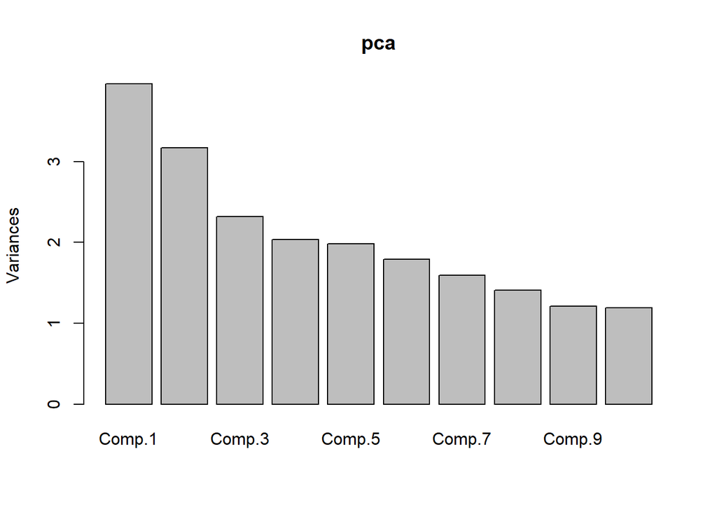

```
##
## Loadings:
##        Comp.1 Comp.2 Comp.3 Comp.4 Comp.5 Comp.6 Comp.7 Comp.8 Comp.9
## V1      0.956  0.266
## V2      0.174 -0.845  0.252  0.248  0.146        -0.141
## V3            -0.142 -0.953  0.188  0.104
## V4                           0.708 -0.691
## V5            -0.140        -0.559 -0.673 -0.267 -0.244
## V6                           0.154        -0.947  0.200
## V7                           0.133               -0.895  0.162
## V8                                                0.137  0.985
## V9                                                              0.971
## V10                                                             0.221
## V11
## V12
## V13
## V14
## V15
## V16
## V17
## V18
## V19
## V20
## V21
## V22
## V23
## V24
## V25
## V26
## V27
## V28
## Amount -0.222  0.391  0.116  0.201  0.143        -0.187
##        Comp.10 Comp.11 Comp.12 Comp.13 Comp.14 Comp.15 Comp.16 Comp.17
## V1
## V2
## V3
## V4
## V5
## V6
## V7
```

[output cut: 84 more lines]

```
## SS loadings     1.000  1.000  1.000  1.000  1.000  1.000  1.000  1.000
## Proportion Var  0.034  0.034  0.034  0.034  0.034  0.034  0.034  0.034
## Cumulative Var  0.034  0.069  0.103  0.138  0.172  0.207  0.241  0.276
##                Comp.9 Comp.10 Comp.11 Comp.12 Comp.13 Comp.14 Comp.15
## SS loadings     1.000   1.000   1.000   1.000   1.000   1.000   1.000
## Proportion Var  0.034   0.034   0.034   0.034   0.034   0.034   0.034
## Cumulative Var  0.310   0.345   0.379   0.414   0.448   0.483   0.517
##                Comp.16 Comp.17 Comp.18 Comp.19 Comp.20 Comp.21 Comp.22
## SS loadings      1.000   1.000   1.000   1.000   1.000   1.000   1.000
## Proportion Var   0.034   0.034   0.034   0.034   0.034   0.034   0.034
## Cumulative Var   0.552   0.586   0.621   0.655   0.690   0.724   0.759
##                Comp.23 Comp.24 Comp.25 Comp.26 Comp.27 Comp.28 Comp.29
## SS loadings      1.000   1.000   1.000   1.000   1.000   1.000   1.000
## Proportion Var   0.034   0.034   0.034   0.034   0.034   0.034   0.034
## Cumulative Var   0.793   0.828   0.862   0.897   0.931   0.966   1.000
```

Doing Principal component analysis gives that the main 2 components are comprised of V1 and V2.

Taking a subset of 15 variables on the basis of PCA to get 80% of the total proportion =================================================

# Naive Bayes

```
##
## Naive Bayes Classifier for Discrete Predictors
##
## Call:
## naiveBayes.default(x = as.matrix(x_train_15), y = factor(y_train))
##
## A-priori probabilities:
## factor(y_train)
##       0       1
## 0.99833 0.00167
##
## Conditional probabilities:
##                V1
## factor(y_train)         [,1]     [,2]
##               0  0.007903952 1.935625
##               1 -4.831154239 6.811838
##
##                V2
## factor(y_train)         [,1]     [,2]
##               0 -0.005161317 1.646375
##               1  3.591932979 4.350533
##
##                V3
## factor(y_train)        [,1]     [,2]
##               0  0.01323081 1.457627
##               1 -6.96000597 7.118649
##
##                V4
## factor(y_train)         [,1]     [,2]
##               0 -0.005223221 1.399436
##               1  4.488476409 2.812871
##
##                V5
## factor(y_train)         [,1]     [,2]
##               0  0.006609917 1.343361
##               1 -3.201350058 5.398700
##
##                V6
## factor(y_train)          [,1]     [,2]
##               0  0.0009866149 1.323551
```

[output cut: 31 more lines]

```
##
##                V13
## factor(y_train)         [,1]      [,2]
##               0 -0.000956564 0.9936044
##               1 -0.132991509 1.1196767
##
##                V14
## factor(y_train)        [,1]      [,2]
##               0  0.01286634 0.8963925
##               1 -6.87287856 4.2035759
##
##                V15
## factor(y_train)         [,1]      [,2]
##               0  0.001244678 0.9163487
##               1 -0.134132158 1.0639919
```

```
##
## pred_Bayes2     0     1
##           0 83203    28
##           1  1446   130
```

# Chisq test

```
##
##  Pearson's Chi-squared test with Yates' continuity correction
##
## data:  bayesConfusionMatrix2
## X-squared = 5569.2, df = 1, p-value < 2.2e-16
```

# Metrics

```
## [1] "BayesAccuracy2"    "0.982619359251005"
```

```
## [1] "Bayes_precision2"  "0.999663586884694"
```

```
## [1] "Bayes_recall2"     "0.982917695424636"
```

```
## [1] "Bayes_Spec2"       "0.822784810126582"
```

```
## [1] "Bayes_F1_2"        "0.991219918989754"
```

# Linear discriminant analysis

```
## Call:
## lda((y_train) ~ as.matrix(x_train1_15))
##
## Prior probabilities of groups:
##       0       1
## 0.99833 0.00167
##
## Group means:
##   as.matrix(x_train1_15)V1 as.matrix(x_train1_15)V2
## 0              0.007903952             -0.005161317
## 1             -4.831154239              3.591932979
##   as.matrix(x_train1_15)V3 as.matrix(x_train1_15)V4
## 0               0.01323081             -0.005223221
## 1              -6.96000597              4.488476409
##   as.matrix(x_train1_15)V5 as.matrix(x_train1_15)V6
## 0              0.006609917             0.0009866149
## 1             -3.201350058            -1.3403022480
##   as.matrix(x_train1_15)V7 as.matrix(x_train1_15)V8
## 0               0.00792044             0.0004624303
## 1              -5.56180870             0.4884512517
##   as.matrix(x_train1_15)V9 as.matrix(x_train1_15)V10
## 0              0.005878499                0.01068207
## 1             -2.605807271               -5.58379456
##   as.matrix(x_train1_15)V11 as.matrix(x_train1_15)V12
## 0              -0.007612328                  0.010889
## 1               3.740707287                 -6.127324
##   as.matrix(x_train1_15)V13 as.matrix(x_train1_15)V14
## 0              -0.000956564                0.01286634
## 1              -0.132991509               -6.87287856
##   as.matrix(x_train1_15)V15
## 0               0.001244678
## 1              -0.134132158
##
## Coefficients of linear discriminants:
##                                   LD1
## as.matrix(x_train1_15)V1  -0.11171799
## as.matrix(x_train1_15)V2   0.11729007
## as.matrix(x_train1_15)V3  -0.26842915
## as.matrix(x_train1_15)V4   0.19808678
## as.matrix(x_train1_15)V5  -0.14859622
## as.matrix(x_train1_15)V6  -0.06754804
## as.matrix(x_train1_15)V7  -0.32185955
## as.matrix(x_train1_15)V8   0.02958088
## as.matrix(x_train1_15)V9  -0.19123525
## as.matrix(x_train1_15)V10 -0.41909569
## as.matrix(x_train1_15)V11  0.31965168
## as.matrix(x_train1_15)V12 -0.54775515
## as.matrix(x_train1_15)V13 -0.01286909
## as.matrix(x_train1_15)V14 -0.66379575
## as.matrix(x_train1_15)V15 -0.01207945
```

# Confusion Matrix

```
##          y_test
## pred_Lda2     0     1
##         0 84625    43
##         1    24   115
```

# Metrics

```
## [1] "Lda_Accuracy2"     "0.999209970875046"
```

```
## [1] "Lda_precision2"    "0.999492133982142"
```

```
## [1] "Lda_recall2"       "0.999716476272608"
```

```
## [1] "Lda_Spec2"         "0.727848101265823"
```

```
## [1] "Lda_F1_2"          "0.999604292540028"
```

# Classification

[figure not shown]

# Confusion Matrix

```
##            y_test
## pred_CTree2     0     1
##           0 84638    49
##           1    11   109
```

# Chisq Test

```
##
##  Pearson's Chi-squared test with Yates' continuity correction
##
## data:  cTreeConfusionMatrix2
## X-squared = 52612, df = 1, p-value < 2.2e-16
```

# Metrics

```
## [1] "cTree_accuracy2"   "0.999292511231384"
```

```
## [1] "cTree_precision2"  "0.999421398797926"
```

```
## [1] "cTree_recall2"     "0.999870051624945"
```

```
## [1] "cTree_Spec2"       "0.689873417721519"
```

```
## [1] "cTree_F1_2"        "0.999645674871262"
```

# C4.5

```
##
## === Summary ===
##
## Correctly Classified Instances      199932               99.966  %
## Incorrectly Classified Instances        68                0.034  %
## Kappa statistic                          0.8884
## Mean absolute error                      0.0007
## Root mean squared error                  0.0183
## Relative absolute error                 20.1302 %
## Root relative squared error             44.9001 %
## Total Number of Instances           200000
##
## === Confusion Matrix ===
##
##       a      b   <-- classified as
##  199661      5 |      a = 0
##      63    271 |      b = 1
```

# Confusion Matrix

```
##            y_test
## pred_C4.5_2     0     1
##           0 84640    35
##           1     9   123
```

# Chisq Test

```
##
##  Pearson's Chi-squared test with Yates' continuity correction
##
## data:  C4.5ConfusionMatrix2
## X-squared = 60984, df = 1, p-value < 2.2e-16
```

# Metrics

```
## [1] "C4.5_accuracy2"    "0.999481174903015"
```

```
## [1] "C4.5_precision2"   "0.999586654856805"
```

```
## [1] "C4.5_recall2"      "0.999893678602228"
```

```
## [1] "C4.5_Spec2"        "0.778481012658228"
```

```
## [1] "C4.5_F1_2"         "0.999740143157497"
```

# C5.0

```
##
## Call:
## C5.0.default(x = x_train_15, y = factor(y_train), trials = 20, rules
##  = FALSE)
##
## Classification Tree
## Number of samples: 200000
## Number of predictors: 15
##
## Number of boosting iterations: 20 requested;  12 used due to early stopping
## Average tree size: 8.6
##
## Non-standard options: attempt to group attributes
```

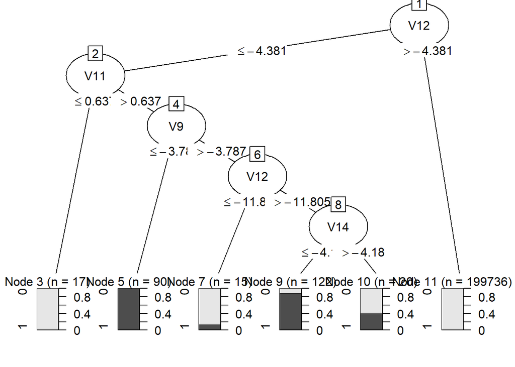

# Confusion Matrix

```
##            y_test
## pred_C5.0_2     0     1
##           0 84626    37
##           1    23   121
```

# Chisq Test

```
##
##  Pearson's Chi-squared test with Yates' continuity correction
##
## data:  C5.0ConfusionMatrix2
## X-squared = 54075, df = 1, p-value < 2.2e-16
```

# Metrics

```
## [1] "C5.0_Accuracy2"    "0.999292511231384"
```

```
## [1] "C5.0_precision2"   "0.999562973199627"
```

```
## [1] "C5.0_recall2"      "0.999728289761249"
```

```
## [1] "C5.0_Spec2"        "0.765822784810127"
```

```
## [1] "C5.0_F1_2"         "0.999645624645625"
```

# Logit

```
##
## Call:  glm(formula = y_train ~ as.matrix(x_train1_15), family = binomial(link = "logit"))
##
## Coefficients:
##               (Intercept)   as.matrix(x_train1_15)V1
##                 -8.276628                  -0.040532
##  as.matrix(x_train1_15)V2   as.matrix(x_train1_15)V3
##                 -0.005695                   0.111286
##  as.matrix(x_train1_15)V4   as.matrix(x_train1_15)V5
##                  0.465231                  -0.063856
##  as.matrix(x_train1_15)V6   as.matrix(x_train1_15)V7
##                 -0.078281                  -0.030474
##  as.matrix(x_train1_15)V8   as.matrix(x_train1_15)V9
##                 -0.196388                  -0.118860
## as.matrix(x_train1_15)V10  as.matrix(x_train1_15)V11
##                 -0.302541                   0.163058
## as.matrix(x_train1_15)V12  as.matrix(x_train1_15)V13
##                 -0.301994                  -0.305624
## as.matrix(x_train1_15)V14  as.matrix(x_train1_15)V15
##                 -0.667181                  -0.067237
##
## Degrees of Freedom: 199999 Total (i.e. Null);  199984 Residual
## Null Deviance:       4939
## Residual Deviance: 1602  AIC: 1634
```

```
##            y_test
## pred_logit2     0     1
##           0 84627    60
##           1    22    98
```

```
##
##  Pearson's Chi-squared test with Yates' continuity correction
##
## data:  logitConfusionMatrix2
## X-squared = 42465, df = 1, p-value < 2.2e-16
```

# Metrics

```
## [1] "lg_Accuracy2"      "0.999033098682892"
```

```
## [1] "lg_precision2"     "0.999291508732155"
```

```
## [1] "lg_recall2"        "0.999740103249891"
```

```
## [1] "lg_Spec2"          "0.620253164556962"
```

```
## [1] "lg_F1_2"           "0.999515755657391"
```

# Probit

```
##
## Call:  glm(formula = y_train ~ as.matrix(x_train1_15), family = binomial(link = "probit"))
##
## Coefficients:
##               (Intercept)   as.matrix(x_train1_15)V1
##                -3.619e+00                 -1.412e-02
##  as.matrix(x_train1_15)V2   as.matrix(x_train1_15)V3
##                 7.379e-05                  1.921e-02
##  as.matrix(x_train1_15)V4   as.matrix(x_train1_15)V5
##                 1.794e-01                 -1.350e-02
##  as.matrix(x_train1_15)V6   as.matrix(x_train1_15)V7
##                -3.790e-02                 -2.615e-03
##  as.matrix(x_train1_15)V8   as.matrix(x_train1_15)V9
##                -7.833e-02                 -8.864e-02
## as.matrix(x_train1_15)V10  as.matrix(x_train1_15)V11
##                -9.398e-02                  2.721e-02
## as.matrix(x_train1_15)V12  as.matrix(x_train1_15)V13
##                -9.543e-02                 -1.162e-01
## as.matrix(x_train1_15)V14  as.matrix(x_train1_15)V15
##                -2.729e-01                 -1.354e-02
##
## Degrees of Freedom: 199999 Total (i.e. Null);  199984 Residual
## Null Deviance:       4939
## Residual Deviance: 1545  AIC: 1577
```

```
##             y_test
## pred_probit2     0     1
##            0 84630    72
##            1    19    86
```

```
##
##  Pearson's Chi-squared test with Yates' continuity correction
##
## data:  probitConfusionMatrix2
## X-squared = 37314, df = 1, p-value < 2.2e-16
```

# Metrics

```
## [1] "pb_Accuracy2"      "0.998926975367599"
```

```
## [1] "pb_precision2"     "0.999149961039881"
```

```
## [1] "pb_recall2"        "0.999775543715815"
```

```
## [1] "pb_Spec2"          "0.544303797468354"
```

```
## [1] "pb_F1_2"           "0.999462654486835"
```

# creating data frame

populating the dataframe

```
##                    algorithms2 Accuracy2 Precision2 Specificity2   Recall2
## 1                  Naive Bayes 0.9826194  0.9996636    0.8227848 0.9829177
## 2 Linear Discriminant Analysis 0.9992100  0.9994921    0.7278481 0.9997165
## 3                       Probit 0.9989270  0.9991500    0.5443038 0.9997755
## 4                        Logit 0.9990331  0.9992915    0.6202532 0.9997401
## 5          Classification Tree 0.9992925  0.9994214    0.6898734 0.9998701
## 6                         C4.5 0.9994812  0.9995867    0.7784810 0.9998937
## 7                         C5.0 0.9992925  0.9995630    0.7658228 0.9997283
##    F1Score2
## 1 0.9912199
## 2 0.9996043
## 3 0.9994627
## 4 0.9995158
## 5 0.9996457
## 6 0.9997401
## 7 0.9996456
```

Before PCA

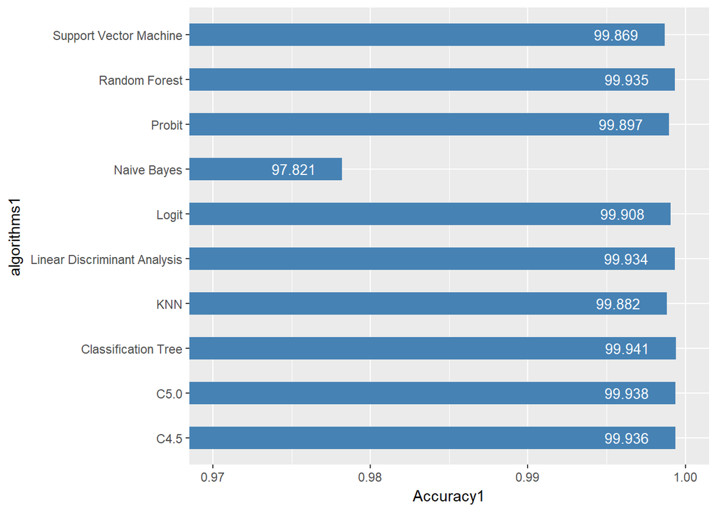

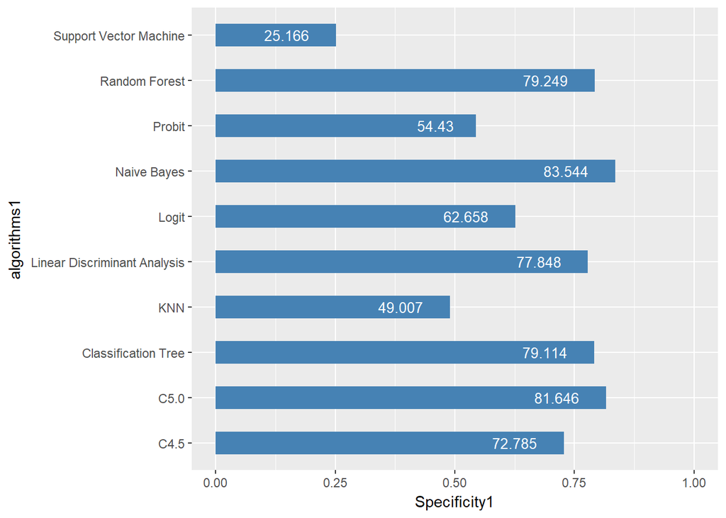

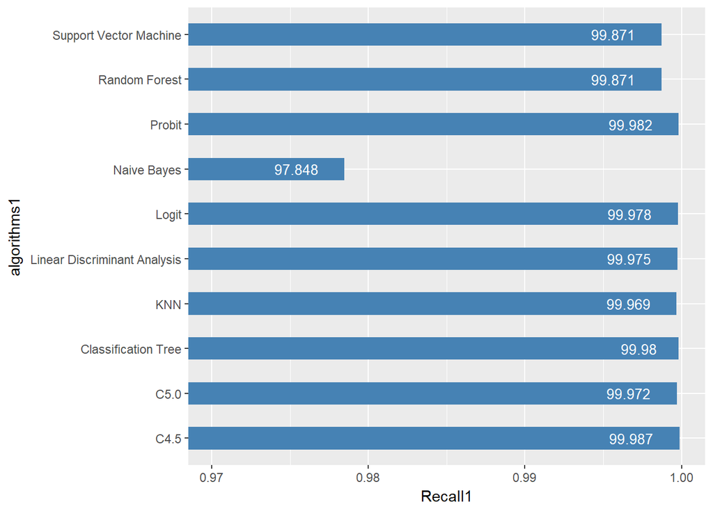

After PCA

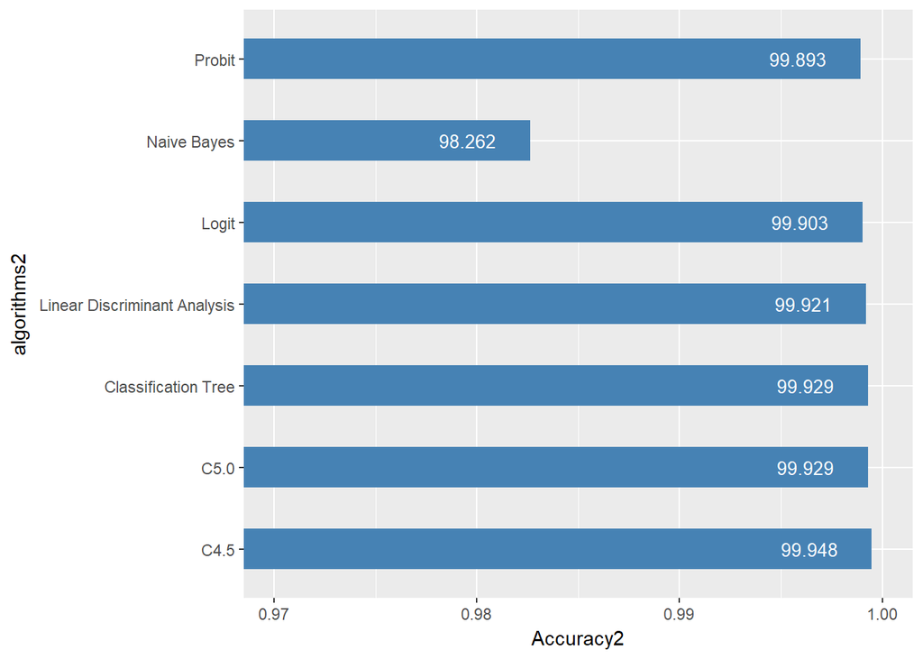

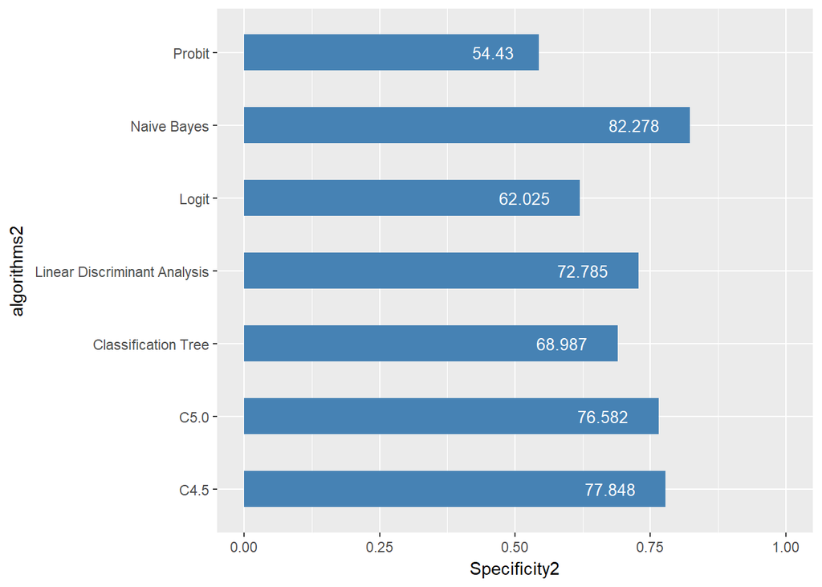

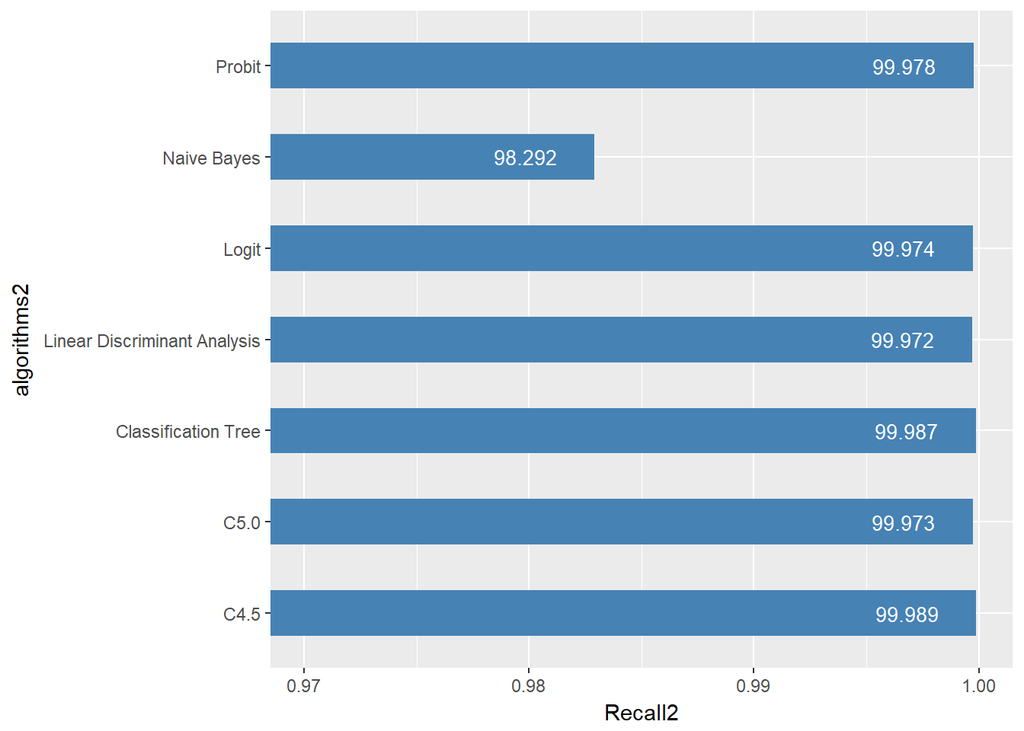

```
## [1] "auc_bayes: "      "0.90695943083509"
```

```
## [1] "auc_lda: "        "0.88911646469838"
```

```
## [1] "auc_ctree: "       "0.895469205599713"
```

```
## [1] "auc_c45: "         "0.863859076445384"
```

```
## [1] "auc_c50: "        "0.90808608623757"
```

```
## [1] "auc_logit: "       "0.813178911098414"
```

```
## [1] "auc_probit: "      "0.772063297569367"
```

```
## [1] "auc_boost: "      "0.91449789458211"
```

```
## [1] "auc_svm: "         "0.625810791940789"
```

```
## [1] "auc_rf: "         "0.89609781976576"
```

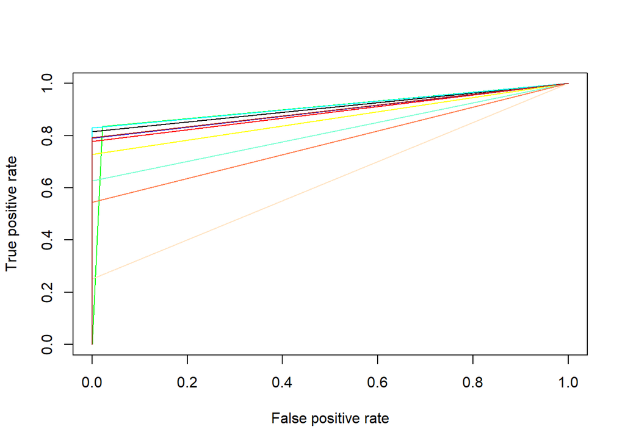

```
##                      algorithms3 Accuracy3 Specificity3   Recall3
## 1                C4.5 Before PCA 0.9994222    0.7434211 0.9998819
## 2                 C4.5 After PCA 0.9993633    0.6907895 0.9999173
## 3                 LDA Before PCA 0.9994104    0.7565789 0.9998464
## 4                  LDA After PCA 0.9992336    0.6907895 0.9997874
## 5                C5.0 Before PCA 0.9993868    0.7565789 0.9998228
## 6                 C5.0 After PCA 0.9993161    0.7039474 0.9998464
## 7 Classification Tree Before PCA 0.9993633    0.7368421 0.9998346
## 8  Classification Tree After PCA 0.9994104    0.7302632 0.9998937
```

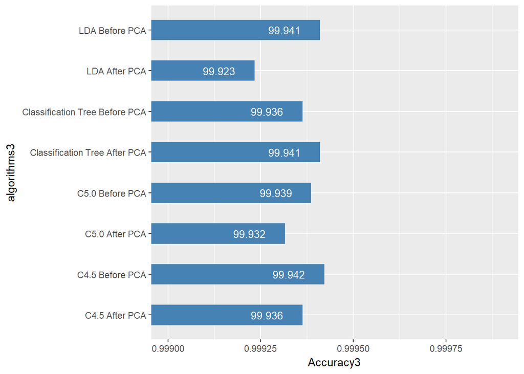

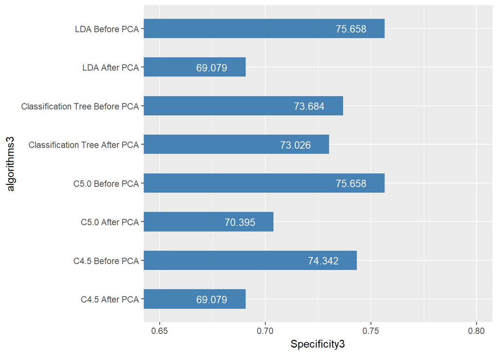

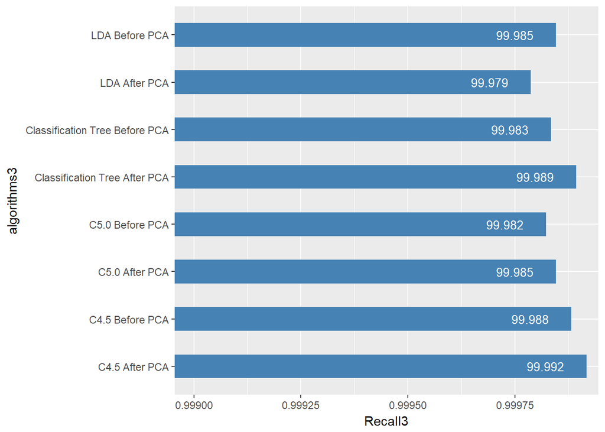